# Soay Sheep Fitness Analysis

Pascal Bärtschi

2023-08-23

### Introduction

In this analysis, we will explore the relationship between body size and fitness in Soay sheep using data analysis techniques. We’ll load the required libraries, read in the data, and perform relevant statistical tests to understand this relationship. Let’s get started!

### Setup

Next, we’ll import the necessary libraries for our analysis.

```r
suppressPackageStartupMessages({
  library("ggplot2")
  library("dplyr")
  library("ggfortify")
  library('tidyverse')
  library('GGally')
  library('MASS')
  library('readr')
  library("PASWR")
})
```

### Data Loading and Exploration

We’ll load the data from the ‘soaysheepfitness.csv’ file and gain initial insights into its structure.

```r
data <- read.csv('data/SoaySheepFitness.csv', stringsAsFactors = T)
glimpse(data)
```

```
## Rows: 50
## Columns: 2
## $ fitness   <int> 4, 3, 2, 14, 5, 2, 2, 5, 8, 4, 12, 6, 3, 2, 3, 0, 5, 3, 5, 6~
## $ body.size <dbl> 6.373546, 7.183643, 6.164371, 8.595281, 7.329508, 6.179532, ~
```

### Quick Visualization of Data

Let’s visualize the relationship between body size and fitness using scatter plots and smoothed lines.

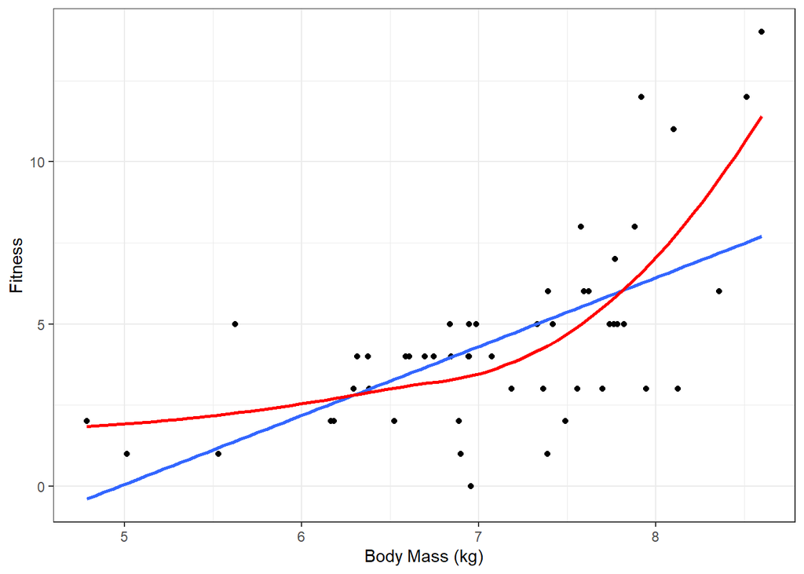

```r
ggplot(data, aes(x = body.size, y = fitness)) +
  geom_point() +
  geom_smooth(method = 'lm', se = FALSE) +
  geom_smooth(span = 1, color = 'red', se = FALSE) +
  xlab('Body Mass (kg)') + ylab('Fitness') +
  theme_bw()
```

### Linear Regression Analysis

We’ll perform a linear regression analysis to understand the relationship between body size and fitness.

```r
m1 <- lm(fitness ~ body.size, data)
summary(m1)
```

```
##
## Call:
## lm(formula = fitness ~ body.size, data = data)
##
## Residuals:
##     Min      1Q  Median      3Q     Max
## -4.2114 -1.1557  0.0029  0.9035  6.3068
##
## Coefficients:
##             Estimate Std. Error t value Pr(>|t|)
## (Intercept) -10.5526     2.8688  -3.678 0.000593 ***
## body.size     2.1228     0.4013   5.289 2.99e-06 ***
## ---
## Signif. codes:  0 '***' 0.001 '**' 0.01 '*' 0.05 '.' 0.1 ' ' 1
##
## Residual standard error: 2.336 on 48 degrees of freedom
## Multiple R-squared:  0.3682, Adjusted R-squared:  0.3551
## F-statistic: 27.98 on 1 and 48 DF,  p-value: 2.99e-06
```

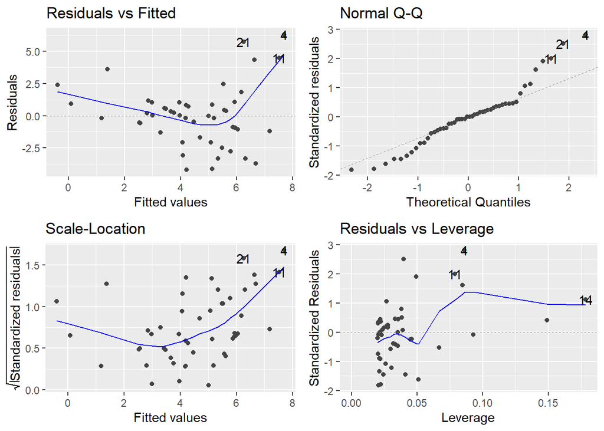

```r
autoplot(m1)
```

There seems to be a clear relationship between residuals and fit.

### GLM with Poisson Family

Now, let’s explore the relationship using a GLM with the Poisson family and log link function.

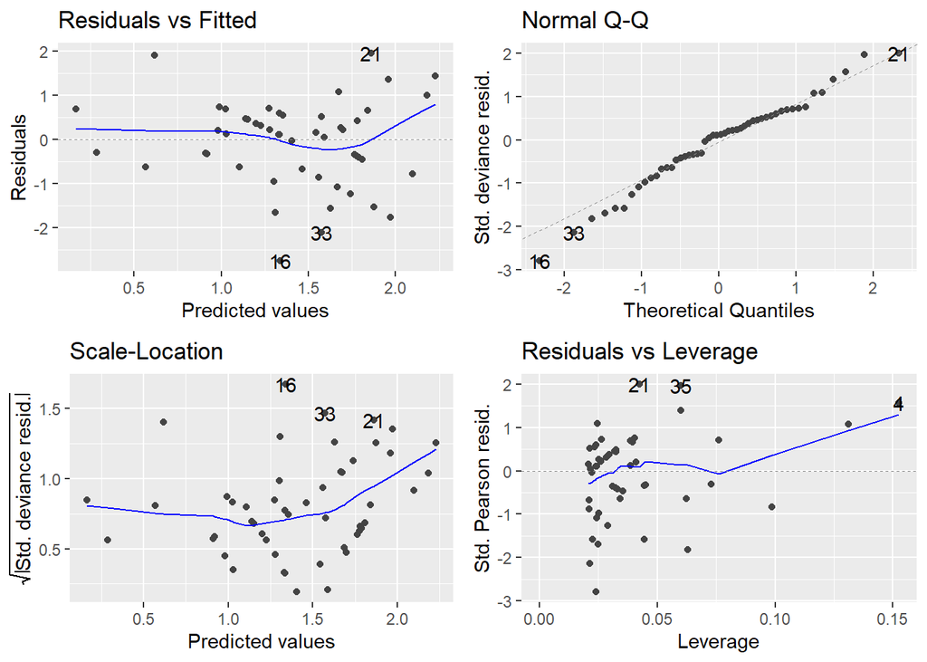

```r
soay.glm <- glm(fitness ~ body.size, data = data, family = poisson(link = log))
autoplot(soay.glm)
```

No clear pattern in residuals, slight correlation of scale location plot.

### ANOVA and Deviance

We’ll perform ANOVA and examine deviance to assess the model fit.

```r
anova(soay.glm, test = 'Chisq')
```

```
## Analysis of Deviance Table
##
## Model: poisson, link: log
##
## Response: fitness
##
## Terms added sequentially (first to last)
##
##
##           Df Deviance Resid. Df Resid. Dev  Pr(>Chi)
## NULL                         49     85.081
## body.size  1   37.041        48     48.040 1.157e-09 ***
## ---
## Signif. codes:  0 '***' 0.001 '**' 0.01 '*' 0.05 '.' 0.1 ' ' 1
```

```r
summary(soay.glm)
```

```
##
## Call:
## glm(formula = fitness ~ body.size, family = poisson(link = log),
##     data = data)
##
## Deviance Residuals:
##     Min       1Q   Median       3Q      Max
## -2.7634  -0.6275   0.1142   0.5370   1.9578
##
## Coefficients:
##             Estimate Std. Error z value Pr(>|z|)
## (Intercept) -2.42203    0.69432  -3.488 0.000486 ***
## body.size    0.54087    0.09316   5.806 6.41e-09 ***
## ---
## Signif. codes:  0 '***' 0.001 '**' 0.01 '*' 0.05 '.' 0.1 ' ' 1
##
## (Dispersion parameter for poisson family taken to be 1)
##
##     Null deviance: 85.081  on 49  degrees of freedom
## Residual deviance: 48.040  on 48  degrees of freedom
## AIC: 210.85
##
## Number of Fisher Scoring iterations: 4
```

### Prediction and Visualization

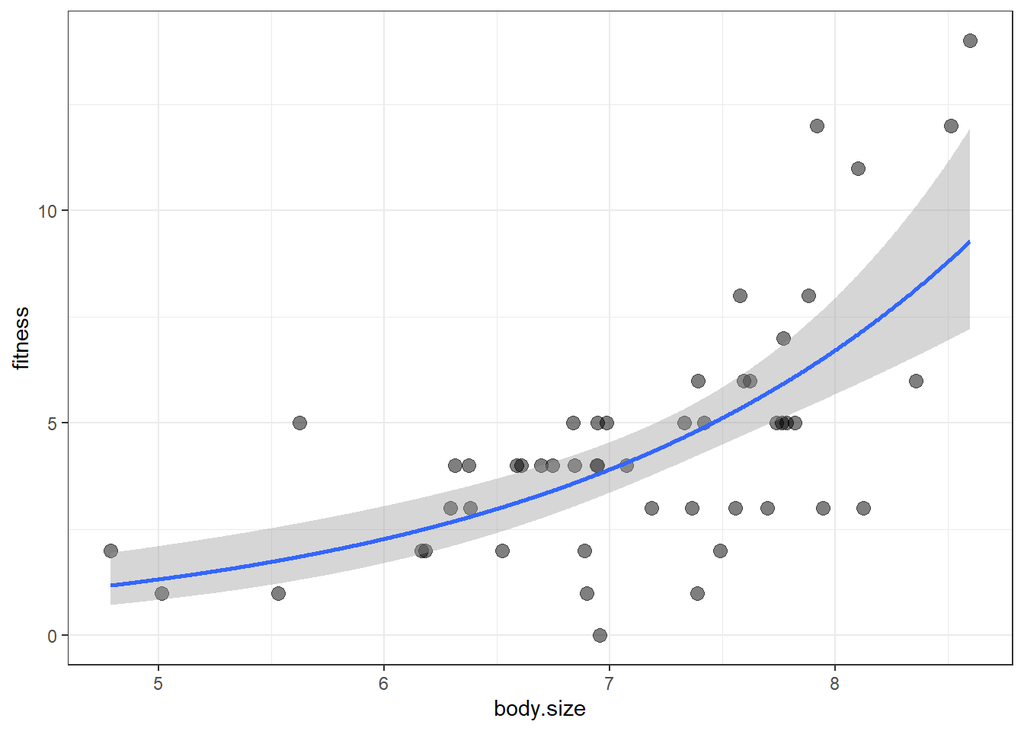

```r
minsize <- min(data$body.size)
maxsize <- max(data$body.size)

# construct new with expand grid
new.x <- expand.grid(body.size = seq(minsize, maxsize, length = 1000))
new.y <- predict(soay.glm, newdata = new.x, se.fit = TRUE)
new.y <- data.frame(new.y)

addThese <- data.frame(new.x, new.y)
# here, it is very important to unlog the values with exp()
addThese <- mutate(addThese,
                   fitness = exp(fit),
                   lwr = exp(fit - 1.96 * se.fit),
                   upr = exp(fit + 1.96 * se.fit))

ggplot(data, aes(x = body.size, y = fitness)) +
  geom_point(size = 3, alpha = .5) +
  geom_smooth(data = addThese,
              aes(ymin = lwr, ymax = upr), stat = 'identity') +
  theme_bw()
```

### Maximum Likelihood and GLMs

Let’s explore the concept of maximum likelihood and GLMs using the janka dataset.

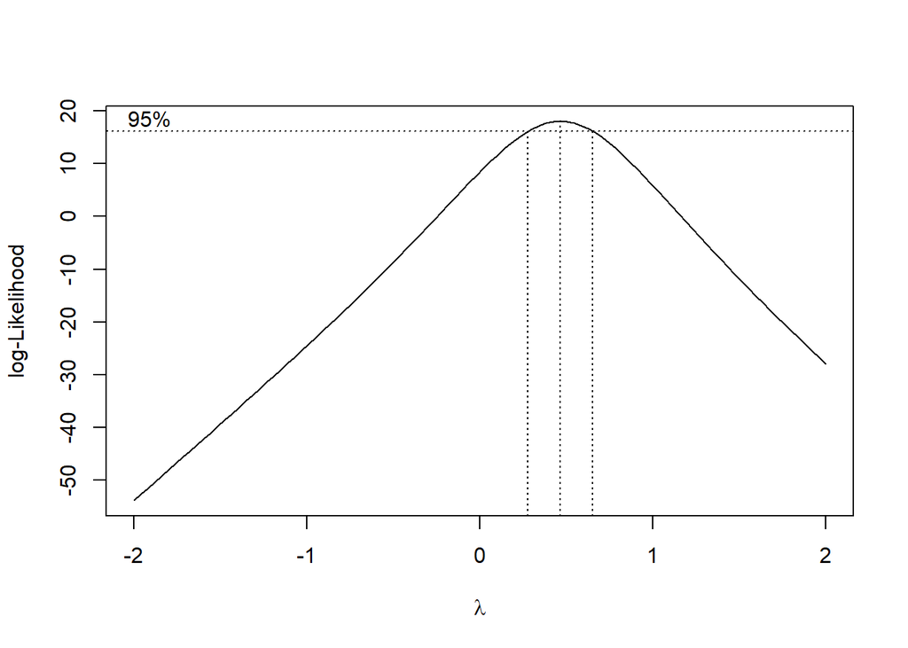

```r
data(janka)

janka.ls1 <- lm(Hardness ~ Density, data = janka)
janka.ml1 <- glm(Hardness ~ Density, data = janka, family = gaussian(link = 'identity'))

boxcox(janka.ls1)
```

### Conclusion

This analysis provides insights into the relationship between body size and fitness in Soay sheep. We’ve used linear regression and GLMs to understand this relationship, and the resulting visualizations help in interpreting the findings.